# Sociedade, Natureza e Modernidade

Análise Ambiental · Aula 2.1

Prof. Dr. Luiz Diego Vidal Santos

## Abertura Visão Geral da Aula

Roteiro da aula Tópicos da Aula 2.1

- 1 Modernidade, razão instrumental e crise ambiental
- 2 A ideia de natureza na história do pensamento (Porto-Gonçalves e Casseti)
- 3 Primeira e Segunda Natureza e os Meios Geográficos (Milton Santos)
- 4 Racionalidade Econômica vs. Racionalidade Ambiental (Enrique Leff)
- 5 Conflitos socioambientais e Justiça Ambiental no Brasil e na Bahia
- 6 Discussão e entrega do Estudo Orientado nº 1

Objetivo da aula Dicotomia Sociedade–Natureza

Analisar a constituição histórica e filosófica da dicotomia Sociedade–Natureza na modernidade ocidental e compreender como a Geografia crítica e socioambiental explica a produção técnica do espaço, a apropriação desigual dos recursos naturais e os conflitos territoriais.

Razão Instrumental Meios Geográficos Justiça Ambiental

# Modernidade e Questão Ambiental

## Epistemologia Gênese Histórica da Cisão Sociedade–Natureza

| Período | Marco Histórico-Epistemológico | Consequência para a Natureza |
| --- | --- | --- |
| **Séc. XVI–XVII** | Revolução Científica (Bacon, Descartes, Galileu, Newton) | **Dessacralização e mecanicismo**: natureza como *res extensa* (objeto mensurável, exterior ao sujeito) |
| **Séc. XVIII–XIX** | Revolução Industrial (carvão, máquina a vapor, urbanização) | Subordinação dos ciclos biogeoquímicos e do tempo geológico ao **tempo abstrato do capital** |
| **Séc. XIX** | Ciência parcelar e Positivismo | Separação rígida entre **Ciências da Natureza** e **Ciências do Homem** (cisma na Geografia) |
| **Pós-1945** | Grande Aceleração (petroquímica, Revolução Verde, nuclear) | Escala global de poluição transfronteiriça, erosão genética e esgotamento de estoques |
| **1972–presente** | Estocolmo (1972), Brundtland (1987), Rio-92, Rio+20 | Institucionalização da **questão ambiental** como arena geopolítica e científica |

Porto-Gonçalves, 1989 Os (des)caminhos do meio ambiente

Toda sociedade institui um conceito de natureza a partir de suas relações sociais. Na modernidade capitalista, o postulado da **dominação da natureza pelo homem** oculta a **dominação de determinados grupos sociais sobre outros** por meio do controle territorial dos recursos.

A crise ecológica moderna nasce como crise de civilização e de modelo de apropriação espacial.

## Epistemologia A Crítica à Razão Instrumental

Ilusão 01 · Sources Inesgotabilidade das fontes

Crença de que jazidas minerais, solos férteis, água doce e florestas seriam infinitos ou integralmente substituíveis por capital artificial.

Ilusão 02 · Sinks Capacidade infinita dos sumidouros

Suposição de que a atmosfera, os oceanos e as bacias hidrográficas absorveriam indefinidamente efluentes, agrotóxicos e gases de efeito estufa.

Ilusão 03 · Tecnocracia Neutralidade da técnica

Mito de que qualquer dano ecológico gerado por uma tecnologia seria automaticamente resolvido por outra tecnologia futura, sem alterar o padrão de acumulação.

Consequência 1 · Mecanismo biofísico Como o sistema natural funciona?

Avaliar dinâmica de fluxos, capacidade de suporte e resposta morfodinâmica à intervenção (sem reduzir o diagnóstico a inventário físico-químico neutro).

Consequência 2 · Intencionalidade social Quem decide e quem arca?

Identificar *quem* se apropria do recurso, *quem* define a localização do empreendimento e *quem* suporta o passivo ambiental no território.

# Produção do Espaço e Meios Geográficos

## Epistemologia Da Natureza Primária ao Meio Técnico-Científico-Informacional

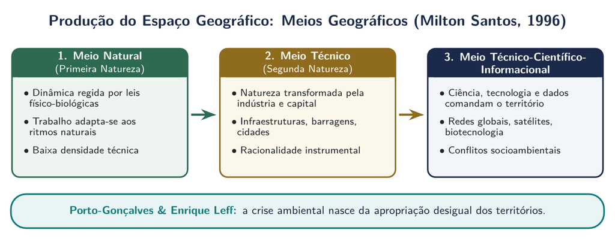

Síntese didática da sucessão dos meios geográficos segundo Milton Santos e da transição entre Primeira e Segunda Natureza.

Sucessão dos Meios Geográficos (Milton Santos, 1996) Da Primeira Natureza ao Meio Técnico-Científico-Informacional; síntese com Porto-Gonçalves e Enrique Leff

A sucessão histórica dos meios altera a densidade técnica e informacional do território, acentuando conflitos quando a apropriação dos recursos é desigual.

## Território Primeira e Segunda Natureza e Sucessão dos Meios

Marx · Casseti (1991) · Suertegaray (2001) Primeira vs. Segunda Natureza

- **Primeira Natureza:** anterior à ação humana ou regida por leis biofísicas e geológicas originais.
- **Segunda Natureza:** transformada pelo trabalho social (cidades, represas, solos corrigidos, canais). **Não anula a Primeira:** um canal em concreto segue regido pela gravidade e pela vazão de pico!

**1. Meio Natural:** dependência direta dos ritmos biofísicos; técnicas simbióticas adaptadas aos ecossistemas locais.

**2. Meio Técnico (Revoluções Industriais):** mecanização e objetos técnicos (ferrovias, barragens, monoculturas) superpostos à natureza.

**3. Meio Técnico-Científico-Informacional (Pós-1970):** ciência, tecnologia e informação comandam o território (transgênicos, agricultura de precisão, hidrelétricas, satélites e financeirização).

[figure not shown]

Usina Hidrelétrica de Sobradinho (Chesf), no Rio São Francisco, Bahia.

Usina Hidrelétrica de Sobradinho (BA) Segunda Natureza e Meio Técnico-Científico-Informacional reconfigurando o Rio São Francisco

## Epistemologia Racionalidade Econômica vs. Racionalidade Ambiental

Enrique Leff (2001, 2006) Racionalidade Econômica Instrumental

- Tempo curto do giro do capital e da taxa de desconto financeiro.
- Homogeneização ecológica (monoculturas em larga escala) para maximizar produtividade imediata por hectare.
- Danos hidrossedimentológicos e sociais tratados como meras **externalidades negativas**.

Saber Ambiental Racionalidade Ambiental

- Respeito aos **tempos de regeneração biogeoquímica e pedogenética** (formar $1\text{ cm}$ de solo leva séculos).
- Valorização da diversidade ecológica e das **territorialidades tradicionais** (produtividade ecotecnológica).

| Dimensão | Lógica Setorial-Mercantil | Análise Ambiental Integrada |
| --- | --- | --- |
| **Unidade de gestão** | Lote / Propriedade isolada | **Bacia Hidrográfica / Geossistema** |
| **Horizonte temporal** | Safra anual ou mandato (1–4 anos) | Ciclos extremos ($TR = 25\text{ a }100\text{ anos}$) e sucessão ecológica |
| **Solo e Água** | Substrato inerte e insumo produtivo | Sistema trifásico vivo e bem de uso comum (Lei 9.433/97) |
| **Indicador de sucesso** | Rentabilidade líquida ($\text{R\$}/\text{ha}$) | Estabilidade morfodinâmica, IQA, APP/RL e equidade social |

# Conflitos Socioambientais e Justiça Ambiental

## Risco Ecologia Política e Injustiça Ambiental (Acselrad, 2004)

Acselrad, 2004 · Zhouri & Laschefski, 2010 Conflito Socioambiental

Disputa entre grupos sociais com modos distintos de apropriação, uso e significação simbólica do território e dos recursos naturais (água, solo, subsolo e biodiversidade).

Desigualdade dos passivos Injustiça Ambiental

Mecanismo pelo qual sociedades desiguais destinam a maior carga dos **danos ambientais do desenvolvimento** (poluição química, rejeitos, lixões, deslizamentos) a baixa renda e trabalhadores.

Dimensão étnico-racial Racismo Ambiental

Expressão étnico-racial da injustiça sobre territórios indígenas, quilombolas, ribeirinhos, marisqueiras, geraizeiros e comunidades de fundo e fecho de pasto.

**Implicação Prática no Licenciamento (EIA/RIMA):** a delimitação da **AID** e da **AII** no diagnóstico socioeconômico não pode ignorar territórios tradicionais e usos múltiplos a jusante (ex.: pescadores artesanais afetados por alteração de vazão ou turbidez).

## Território Conflitos Socioambientais Emblemáticos na Bahia

| Caso na Bahia | Localização / Bioma | Agentes e Pressão | Impacto Físico-Ambiental e Conflito Territorial |
| --- | --- | --- | --- |
| **1. Águas do Aquífero Urucuia** | Oeste Baiano (Correntina, Jaborandi, São Desidério) · Cerrado | Agronegócio irrigado (pivôs centrais e grandes captações) vs. Fecho de Pasto e ribeirinhos | Rebaixamento piezométrico do Aquífero Urucuia, redução da vazão de base dos rios Arrojado e Corrente e disputa por outorgas (INEMA) |
| **2. Eólicas e Mineração nas Serras** | Chapada Diamantina e Piemonte Norte (Campo Formoso, Sento Sé, Caetité) · Caatinga | Parques eólicos/mineradoras em topos de serra vs. Fundo de Pasto e Quilombolas | Supressão vegetal, abertura de acessos em encostas íngremes (erosão e assoreamento de nascentes), cercamento de áreas comunais e ruído |
| **3. Passivo Metalúrgico no Subaé** | Santo Amaro e Baía de Todos-os-Santos · Recôncavo Baiano | Antiga fundição de chumbo (Plumbum/Cobrac) vs. Pescadores, marisqueiras e moradores | Contaminação crônica de solos aluviais, sedimentos estuarinos e biota por metais pesados ($\text{Pb}$ e $\text{Cd}$ — CONAMA 420/2009) |

Em todos os estudos de caso baianos, o passivo físico-químico ou hidrológico é inseparável dos direitos territoriais das comunidades afetadas.

## Campo Oficina de Conflito Socioambiental na Bahia

| Dimensão analítica | Pergunta orientadora |
| --- | --- |
| **Atores e território** | Quem decide, utiliza e controla os recursos? |
| **Distribuição** | Quem recebe os benefícios e quem suporta os impactos? |
| **Conhecimento** | Quais dados técnicos e saberes locais são reconhecidos? |
| **Escala** | Como decisões econômicas ou regulatórias externas chegam ao lugar? |
| **Justiça ambiental** | Quais direitos, alternativas e formas de participação existem? |

**Procedimento:** escolher um caso de água, mineração, energia ou uso comum da terra; usar documentos e fontes identificáveis; distinguir alegações dos atores, fatos documentados e interpretação.

# Fechamento e Referências

## Síntese Síntese da Aula, EO nº 1 e Referências

**1. Contradição estrutural:** a crise ambiental decorre do choque entre a escala de reprodução do capital/técnica e os limites biofísicos e temporais dos sistemas naturais.

**2. Meio Técnico-Científico-Informacional:** a categoria de Milton Santos explica como ciência e técnica remodelam bacias, solos e climas urbanos sem revogar leis físicas e geomorfológicas.

**3. Diagnóstico integrado:** em EIA, ZEE e Planos de Bacia, análise biofísica e análise de conflitos socioambientais são indissociáveis.

**Entrega da semana:** discussão e entrega do **Estudo Orientado nº 1**.

Bibliografia da aula Referências Bibliográficas

- ACSELRAD, H. (Org.). **Conflitos Ambientais no Brasil**. Rio de Janeiro: Relume Dumará, 2004.
- CASSETI, V. **Ambiente e apropriação do relevo**. São Paulo: Contexto, 1991.
- LEFF, E. **Saber ambiental: sustentabilidade, racionalidade, complexidade, poder**. Petrópolis: Vozes, 2001.
- PORTO-GONÇALVES, C. W. **Os (des)caminhos do meio ambiente**. São Paulo: Contexto, 1989.
- SANTOS, M. **A Natureza do Espaço: Técnica e Tempo, Razão e Emoção**. São Paulo: Hucitec, 1996.
- ZHOURI, A.; LASCHEFSKI, K. (Orgs.). **Desenvolvimento e conflitos ambientais**. Belo Horizonte: Ed. UFMG, 2010.